# An Ensemble Model to Predict Whether a News Article is Fake or Real

DA5030

Meseret Ambachew

Spring 2025

# 1 **Introduction: Business Objective**

In today’s fragmented and fast-moving media landscape, misinformation spreads rapidly — often faster than the truth. For **public relations firms**, **media outlets**, and **brand managers**, the stakes are high: one fake news article can damage reputations, distort public narratives, and erode trust. As a result, being able to quickly and reliably distinguish between real and fake news isn’t just a technical challenge — it’s a business imperative.

This project aims to build a predictive model that classifies news articles as *Real* or *Fake* based on a range of data and content features, in other words variables. From a business perspective, such a model has immediate applications: - it could power real-time content verification tools, strengthen media monitoring services, and serve as a safeguard in brand reputation systems. - PR firms could use it to proactively flag misleading stories before they go viral, while media companies might integrate it into editorial pipelines or audience trust platforms.

This project can help identify the signals and behaviors that tend to correlate with misinformation — such as clickbait tendencies, extreme sentiment, or questionable sources. By surfacing these insights, businesses are better equipped to understand and manage the risks posed by false narratives in the public sphere.

Ultimately, this model isn’t just about prediction — it’s about giving communicators the tools to respond faster, protect their credibility, and make smarter decisions in a world where all information is nuanced.

## 1.2 **Methodology**

This project will use four different supervised learning models:

- **Logistic Regression:** As a baseline, it offers interpretability and works well for binary classification, especially when variables are independent and linearly separable
- **k-Nearest Neighbors (kNN):** Chosen for its simplicity and effectiveness on structured data, especially after normalization
- **CART Decision Tree:** A rule-based model that captures non-linear relationships and is easy to visualize and interpret
- **Naive Bayes:** Well-suited for binary text classification problems due to its probabilistic structure and speed, especially when feature independence is assumed.

# 2 **Data Analysis and Prep**

## 2.1 Load Library

## 2.2 Load Data

The data is loaded from a public Google Drive csv.

```r
# ChatGPT helped me write the correct URL from google drive https://chatgpt.com/c/67fd5ff8-7194-8004-8c4e-b4c4d96337a4

url <- "https://drive.google.com/uc?export=download&id=1f6pPuWv9PuaYgFn4mwL9GV421SHLCE-e"

fake.news.df <- read.csv(url,
                     header = T,
                     stringsAsFactors = F)

summary(fake.news.df)
```

```
##        id          title              author              text
##  Min.   :   1   Length:4000        Length:4000        Length:4000
##  1st Qu.:1001   Class :character   Class :character   Class :character
##  Median :2000   Mode  :character   Mode  :character   Mode  :character
##  Mean   :2000
##  3rd Qu.:3000
##  Max.   :4000
##     state           date_published        source            category
##  Length:4000        Length:4000        Length:4000        Length:4000
##  Class :character   Class :character   Class :character   Class :character
##  Mode  :character   Mode  :character   Mode  :character   Mode  :character
##
##
##
##  sentiment_score       word_count       char_count     has_images
##  Min.   :-1.000000   Min.   : 100.0   Min.   : 500   Min.   :0.0000
##  1st Qu.:-0.490000   1st Qu.: 445.8   1st Qu.:2359   1st Qu.:0.0000
##  Median :-0.010000   Median : 793.0   Median :4287   Median :0.0000
##  Mean   :-0.000645   Mean   : 795.7   Mean   :4277   Mean   :0.4965
##  3rd Qu.: 0.510000   3rd Qu.:1150.0   3rd Qu.:6206   3rd Qu.:1.0000
##  Max.   : 1.000000   Max.   :1500.0   Max.   :7996   Max.   :1.0000
##    has_videos     readability_score   num_shares     num_comments
##  Min.   :0.0000   Min.   :30.02     Min.   :   39   Min.   :   0.0
##  1st Qu.:0.0000   1st Qu.:42.48     1st Qu.:12782   1st Qu.: 238.0
##  Median :0.0000   Median :54.23     Median :25308   Median : 483.0
##  Mean   :0.4845   Mean   :54.76     Mean   :25145   Mean   : 489.9
##  3rd Qu.:1.0000   3rd Qu.:67.22     3rd Qu.:37454   3rd Qu.: 741.0
##  Max.   :1.0000   Max.   :79.98     Max.   :50000   Max.   :1000.0
##  political_bias     fact_check_rating   is_satirical    trust_score
##  Length:4000        Length:4000        Min.   :0.000   Min.   :  0.00
##  Class :character   Class :character   1st Qu.:0.000   1st Qu.: 24.00
##  Mode  :character   Mode  :character   Median :0.000   Median : 50.00
##                                        Mean   :0.497   Mean   : 49.96
##                                        3rd Qu.:1.000   3rd Qu.: 76.00
##                                        Max.   :1.000   Max.   :100.00
##  source_reputation clickbait_score  plagiarism_score    label
##  Min.   : 1.000    Min.   :0.0000   Min.   : 0.04    Length:4000
##  1st Qu.: 3.000    1st Qu.:0.2400   1st Qu.:25.91    Class :character
##  Median : 6.000    Median :0.4900   Median :51.48    Mode  :character
##  Mean   : 5.549    Mean   :0.4944   Mean   :50.60
##  3rd Qu.: 8.000    3rd Qu.:0.7400   3rd Qu.:75.58
##  Max.   :10.000    Max.   :1.0000   Max.   :99.95
```

```r
str(fake.news.df)
```

```
## 'data.frame':    4000 obs. of  24 variables:
##  $ id               : int  1 2 3 4 5 6 7 8 9 10 ...
##  $ title            : chr  "Breaking News 1" "Breaking News 2" "Breaking News 3" "Breaking News 4" ...
##  $ author           : chr  "Jane Smith" "Emily Davis" "John Doe" "Alex Johnson" ...
##  $ text             : chr  "This is the content of article 1. It contains detailed analysis and reports." "This is the content of article 2. It contains detailed analysis and reports." "This is the content of article 3. It contains detailed analysis and reports." "This is the content of article 4…
##  $ state            : chr  "Tennessee" "Wisconsin" "Missouri" "North Carolina" ...
##  $ date_published   : chr  "30-11-2021" "02-09-2021" "13-04-2021" "08-03-2020" ...
##  $ source           : chr  "The Onion" "The Guardian" "New York Times" "CNN" ...
##  $ category         : chr  "Entertainment" "Technology" "Sports" "Sports" ...
##  $ sentiment_score  : num  -0.22 0.92 0.25 0.94 -0.01 0.83 0.81 -0.96 -0.64 -0.5 ...
##  $ word_count       : int  1302 322 228 155 962 920 651 717 1093 1421 ...
##  $ char_count       : int  5070 2722 5904 825 1087 4022 5652 737 4362 830 ...
##  $ has_images       : int  0 1 0 1 1 0 0 1 0 0 ...
##  $ has_videos       : int  0 0 1 0 0 0 1 0 0 1 ...
##  $ readability_score: num  66.2 41.1 30 75.2 43.9 ...
##  $ num_shares       : int  47305 39804 45860 34222 35934 13148 13627 6035 49000 30508 ...
##  $ num_comments     : int  450 530 763 945 433 28 665 323 881 782 ...
##  $ political_bias   : chr  "Center" "Left" "Center" "Center" ...
##  $ fact_check_rating: chr  "FALSE" "Mixed" "Mixed" "TRUE" ...
##  $ is_satirical     : int  1 1 0 1 0 0 0 1 1 1 ...
##  $ trust_score      : int  76 1 57 18 95 8 1 79 96 88 ...
##  $ source_reputation: int  6 5 1 10 6 1 10 5 7 3 ...
##  $ clickbait_score  : num  0.84 0.85 0.72 0.92 0.66 0.01 0.47 0.58 0.08 0.68 ...
##  $ plagiarism_score : num  53.35 28.28 0.38 32.2 77.7 ...
##  $ label            : chr  "Fake" "Fake" "Fake" "Fake" ...
```

## 2.3 Inspect Missing Values

```r
# The below is a loop to inspect missing values for each variable
cols <- colnames(fake.news.df)

# missing values in each column: iterate
for (c in cols) {
  missing.rows <- which(is.na(fake.news.df[,c]))

  num.missing <- length(missing.rows)

  s <- "no"

  if (num.missing > 0)
    s <- num.missing

  print(paste0("Column '", c, "' has ",
                 s, " missing values"))}
```

```
## [1] "Column 'id' has no missing values"
## [1] "Column 'title' has no missing values"
## [1] "Column 'author' has no missing values"
## [1] "Column 'text' has no missing values"
## [1] "Column 'state' has no missing values"
## [1] "Column 'date_published' has no missing values"
## [1] "Column 'source' has no missing values"
## [1] "Column 'category' has no missing values"
## [1] "Column 'sentiment_score' has no missing values"
## [1] "Column 'word_count' has no missing values"
## [1] "Column 'char_count' has no missing values"
## [1] "Column 'has_images' has no missing values"
## [1] "Column 'has_videos' has no missing values"
## [1] "Column 'readability_score' has no missing values"
## [1] "Column 'num_shares' has no missing values"
## [1] "Column 'num_comments' has no missing values"
## [1] "Column 'political_bias' has no missing values"
## [1] "Column 'fact_check_rating' has no missing values"
## [1] "Column 'is_satirical' has no missing values"
## [1] "Column 'trust_score' has no missing values"
## [1] "Column 'source_reputation' has no missing values"
## [1] "Column 'clickbait_score' has no missing values"
## [1] "Column 'plagiarism_score' has no missing values"
## [1] "Column 'label' has no missing values"
```

The data has no missing values. Also from the statistical summary there isn’t a huge range between the mean and median, so I will not inspect for outliers and remove them. I’m already using four different models for my ensemble and wouldn’t want it to overfit, so I’ll continue the next step in my data prep.

## 2.4 Remove Unnecessary Variables

For this model, there is no plan to forecast fake news article as the purpose of this model is to accurately predict news as “real” or “fake”, so I will drop the *date_published* variable as it won’t be necessary. I’ll also drop the *“text”* variable as the data reads the same text across 4,000 columns and so does *“title”*.

I’m also dropping the *“author”* variable since some are filled with pseudonyms (John Doe, Jane Doe). Author is also too predictable of an identifier if they are notorious for providing fake or real news. Regardless, we only need one unique identifier for this model which is **id** so we’ll keep for tracking.

```r
# Using the piping method from the 'dplyr' package I'm going to remove the variables date_published, author, text, and title

cleaned_fakenews_df <- fake.news.df %>%
  dplyr::select(-date_published, -title, -text, -author)

head(cleaned_fakenews_df)
```

|  | id | state | source | category | sentiment_score | word_count | char_count | has_images | has_videos | readability_score | num_shares | num_comments | political_bias | fact_check_rating | is_satirical | trust_score | source_reputation | clickbait_score | plagiarism_score | label |
| --- | --- | --- | --- | --- | --- | --- | --- | --- | --- | --- | --- | --- | --- | --- | --- | --- | --- | --- | --- | --- |
| 1 | 1 | Tennessee | The Onion | Entertainment | -0.22 | 1302 | 5070 | 0 | 0 | 66.18 | 47305 | 450 | Center | FALSE | 1 | 76 | 6 | 0.84 | 53.35 | Fake |
| 2 | 2 | Wisconsin | The Guardian | Technology | 0.92 | 322 | 2722 | 1 | 0 | 41.10 | 39804 | 530 | Left | Mixed | 1 | 1 | 5 | 0.85 | 28.28 | Fake |
| 3 | 3 | Missouri | New York Times | Sports | 0.25 | 228 | 5904 | 0 | 1 | 30.04 | 45860 | 763 | Center | Mixed | 0 | 57 | 1 | 0.72 | 0.38 | Fake |
| 4 | 4 | North Carolina | CNN | Sports | 0.94 | 155 | 825 | 1 | 0 | 75.16 | 34222 | 945 | Center | TRUE | 1 | 18 | 10 | 0.92 | 32.20 | Fake |
| 5 | 5 | California | Daily Mail | Technology | -0.01 | 962 | 1087 | 1 | 0 | 43.90 | 35934 | 433 | Right | Mixed | 0 | 95 | 6 | 0.66 | 77.70 | Real |
| 6 | 6 | North Carolina | New York Times | Sports | 0.83 | 920 | 4022 | 0 | 0 | 42.88 | 13148 | 28 | Right | FALSE | 0 | 8 | 1 | 0.01 | 72.10 | Fake |

## 2.5 Variable Encoding: Categorical Variables

```r
# Using sapply I called only the categorical variables in my data to give me a summary on their lengths

sapply(cleaned_fakenews_df[sapply(cleaned_fakenews_df, function(x) is.character(x)
                                  || is.factor(x))],function(x) nlevels(as.factor(x)))
```

```
##             state            source          category    political_bias
##                20                13                 6                 3
## fact_check_rating             label
##                 3                 2
```

### 2.5.1 Frequency Encoding

Below, a loop is used to use frequency encoding for the *state*, *source*, and *category* variables.

```r
vars_to_encode <- c("state", "source", "category")

# Loop created below to apply frequency encoding to each variable listed above

for (var in vars_to_encode) {
  freq_map <- cleaned_fakenews_df %>%
    group_by(.data[[var]]) %>%
    summarise(Frequency = n(), .groups = 'drop') %>%
    mutate(Frequency = Frequency / nrow(cleaned_fakenews_df))  # Relative frequency

  freq_map <- setNames(freq_map$Frequency, freq_map[[var]])

# Replace original column with encoded frequency values
  cleaned_fakenews_df[[var]] <- unname(freq_map[as.character(cleaned_fakenews_df[[var]])])
}

head(cleaned_fakenews_df)
```

|  | id | state | source | category | sentiment_score | word_count | char_count | has_images | has_videos | readability_score | num_shares | num_comments | political_bias | fact_check_rating | is_satirical | trust_score | source_reputation | clickbait_score | plagiarism_score | label |
| --- | --- | --- | --- | --- | --- | --- | --- | --- | --- | --- | --- | --- | --- | --- | --- | --- | --- | --- | --- | --- |
| 1 | 1 | 0.04775 | 0.07850 | 0.15825 | -0.22 | 1302 | 5070 | 0 | 0 | 66.18 | 47305 | 450 | Center | FALSE | 1 | 76 | 6 | 0.84 | 53.35 | Fake |
| 2 | 2 | 0.05075 | 0.07325 | 0.15975 | 0.92 | 322 | 2722 | 1 | 0 | 41.10 | 39804 | 530 | Left | Mixed | 1 | 1 | 5 | 0.85 | 28.28 | Fake |
| 3 | 3 | 0.04575 | 0.08775 | 0.16100 | 0.25 | 228 | 5904 | 0 | 1 | 30.04 | 45860 | 763 | Center | Mixed | 0 | 57 | 1 | 0.72 | 0.38 | Fake |
| 4 | 4 | 0.04550 | 0.08600 | 0.16100 | 0.94 | 155 | 825 | 1 | 0 | 75.16 | 34222 | 945 | Center | TRUE | 1 | 18 | 10 | 0.92 | 32.20 | Fake |
| 5 | 5 | 0.05625 | 0.07675 | 0.15975 | -0.01 | 962 | 1087 | 1 | 0 | 43.90 | 35934 | 433 | Right | Mixed | 0 | 95 | 6 | 0.66 | 77.70 | Real |
| 6 | 6 | 0.04550 | 0.08775 | 0.16100 | 0.83 | 920 | 4022 | 0 | 0 | 42.88 | 13148 | 28 | Right | FALSE | 0 | 8 | 1 | 0.01 | 72.10 | Fake |

Using the piping method, categorical variables like target *label*, and other variables *political_bias* and *fact_check_rating* were encoded numerically to make them compatible with machine learning algorithms. This step ensures the models can interpret these variables as inputs during training and prediction.

```r
# 'label' encoding
cleaned_fakenews_df <- cleaned_fakenews_df %>%
  mutate(label = ifelse(label == "Real", 1, 0)) # using the ifelse() argument to mark "Real" as 1 and "Fake" as 0.

# 'political_bias' encoding
cleaned_fakenews_df <- cleaned_fakenews_df %>%
  mutate(political_bias = ifelse(political_bias == "Left", 0,
                          ifelse(political_bias == "Center", 1, 2)))

# 'fact_check_rating' encoding
cleaned_fakenews_df <- cleaned_fakenews_df %>%
  mutate(fact_check_rating = ifelse(fact_check_rating == "FALSE", 0,
                             ifelse(fact_check_rating == "Mixed", 1, 2)))

head(cleaned_fakenews_df)
```

|  | id | state | source | category | sentiment_score | word_count | char_count | has_images | has_videos | readability_score | num_shares | num_comments | political_bias | fact_check_rating | is_satirical | trust_score | source_reputation | clickbait_score | plagiarism_score | label |
| --- | --- | --- | --- | --- | --- | --- | --- | --- | --- | --- | --- | --- | --- | --- | --- | --- | --- | --- | --- | --- |
| 1 | 1 | 0.04775 | 0.07850 | 0.15825 | -0.22 | 1302 | 5070 | 0 | 0 | 66.18 | 47305 | 450 | 1 | 0 | 1 | 76 | 6 | 0.84 | 53.35 | 0 |
| 2 | 2 | 0.05075 | 0.07325 | 0.15975 | 0.92 | 322 | 2722 | 1 | 0 | 41.10 | 39804 | 530 | 0 | 1 | 1 | 1 | 5 | 0.85 | 28.28 | 0 |
| 3 | 3 | 0.04575 | 0.08775 | 0.16100 | 0.25 | 228 | 5904 | 0 | 1 | 30.04 | 45860 | 763 | 1 | 1 | 0 | 57 | 1 | 0.72 | 0.38 | 0 |
| 4 | 4 | 0.04550 | 0.08600 | 0.16100 | 0.94 | 155 | 825 | 1 | 0 | 75.16 | 34222 | 945 | 1 | 2 | 1 | 18 | 10 | 0.92 | 32.20 | 0 |
| 5 | 5 | 0.05625 | 0.07675 | 0.15975 | -0.01 | 962 | 1087 | 1 | 0 | 43.90 | 35934 | 433 | 2 | 1 | 0 | 95 | 6 | 0.66 | 77.70 | 1 |
| 6 | 6 | 0.04550 | 0.08775 | 0.16100 | 0.83 | 920 | 4022 | 0 | 0 | 42.88 | 13148 | 28 | 2 | 0 | 0 | 8 | 1 | 0.01 | 72.10 | 0 |

## 2.6 Normalize Variables with Continuous Data

I applied **z-score normalization** to all continuous variables. This transformation standardizes each variable to have a mean of 0 and standard deviation of 1, helping distance-based models like kNN and logistic regression perform more effectively without being biased toward larger numerical ranges.

```r
cont_vars <- c( # Created a concatanate of all the variables with continuous data
  "sentiment_score",
  "word_count",
  "char_count",
  "readability_score",
  "num_shares",
  "num_comments",
  "trust_score",
  "clickbait_score",
  "plagiarism_score")

zNormalize <- function(v) { # Applied them to the function written below
  m <- mean(v)
  s <- sd(v)
  return((v - m) / s)}

# Created a new dataframe with the new data
cleaned_fakenews_df_2 <- cleaned_fakenews_df %>%
  mutate(across(all_of(cont_vars), zNormalize))
```

## 2.7 Feature Engineering

To improve model performance, I created four new features that combine existing numeric variables to capture deeper patterns:

- **credibility_clickbait_gap** measures the difference between *trustworthiness* and *clickbait*, flagging potentially misleading content.
- **engagement_total** sums *shares* and *comments* to reflect how viral a news article is.
- **content_density** captures writing style by comparing *character* and *word counts.*
- **readability_vs_sentiment** combines *tone* and *readability* to detect emotionally persuasive content.

These engineered features aim to add predictive value and reduce noise, especially for models like logistic regression.

```r
cleaned_fakenews_df_2 <- cleaned_fakenews_df_2 %>%
  mutate(
    credibility_clickbait_gap = trust_score - clickbait_score,
    engagement_total = num_shares + num_comments,
    content_density = char_count / (word_count + 1),  # adding 1 to avoid divide by zero
    readability_vs_sentiment = readability_score * sentiment_score)
```

## 2.8 Examine Multicollinearity

To evaluate multicollinearity among features, I generated a correlation matrix heatmap using all numeric variables in the dataset. The heatmap shows a strong red diagonal, indicating perfect correlation of each variable with itself, which is expected.

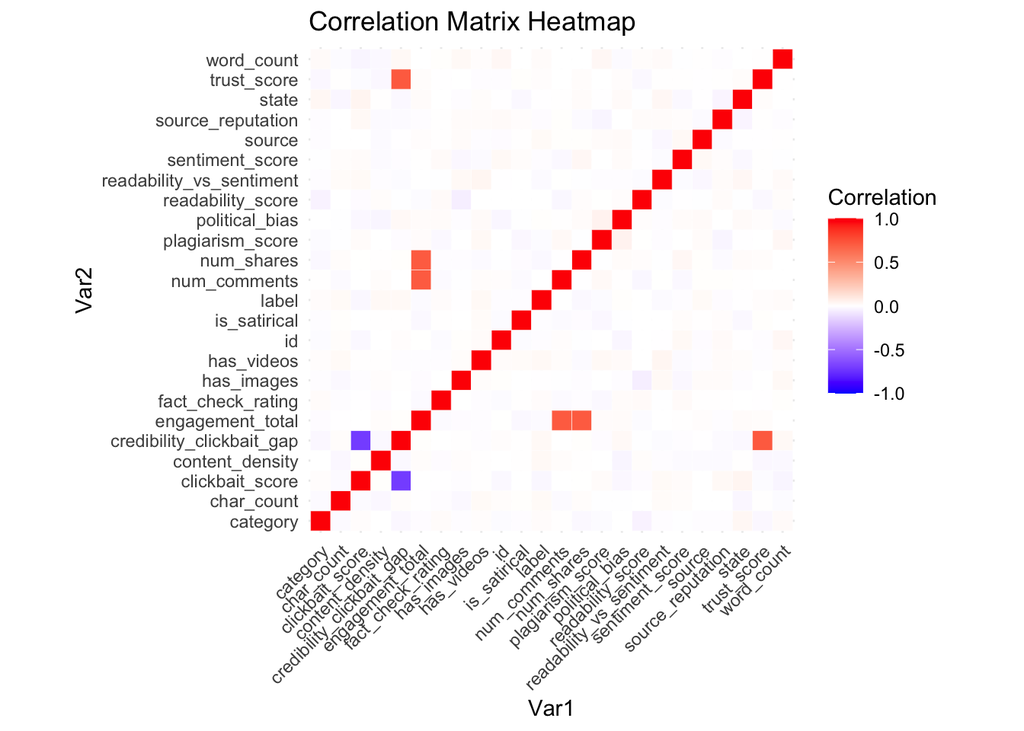

```r
numeric_vars <- cleaned_fakenews_df_2 %>% dplyr::select(where(is.numeric))

# Compute correlation matrix using cor()
cor_matrix <- cor(numeric_vars, use = "complete.obs")

cor_df <- as.data.frame(cor_matrix) %>%
  rownames_to_column(var = "Var1") %>%
  pivot_longer(-Var1, names_to = "Var2", values_to = "Correlation")

# Using ggplot and geom_tile I created a correlation matrix to display it
cor_map <- ggplot(cor_df, aes(x = Var1, y = Var2, fill = Correlation)) +
  geom_tile(color = "white") +
  scale_fill_gradient2(
    low = "blue", high = "red", mid = "white",# assigning colors to range in correlation
    midpoint = 0, limit = c(-1, 1), space = "Lab",
    name = "Correlation"
  ) +
  theme_minimal() +
  theme(axis.text.x = element_text(angle = 45, hjust = 1)) +
  coord_fixed() +
  labs(title = "Correlation Matrix Heatmap")

cor_map
```

- There is **no need to remove or combine** variables based on correlation.
- The current feature set is appropriate for use in both linear models (e.g., logistic regression) and non-linear models (e.g., decision trees, ensemble methods).

The rest of the variables in the dataset came numerically as counts, continuous data, or are categorized as binaries (0-1). Meaning this is ready for the next step of this process, **Building the Model**

### 2.8.1 **NOTE**

Outliers were checked for this dataset with standard deviations of 3 and 1.5, this decreased the amount of data in my dataset heavily with little to no data to build a model with.

# 3 **Model Building**

For this project to help predict whether a news article is “Real” or “Fake,” I’ve selected a diverse set of models that offer a balance of interpretability, simplicity, and predictive power:

- **Logistic Regression:** Useful for identifying linear relationships between content features (e.g., trust score, sentiment) and the article’s label
- **kNN (k-Nearest Neighbor):** Helps detect patterns based on proximity in feature space, especially after normalization
- **Decision Tree (CART):** Helps reveal decision paths and thresholds (e.g., trust score < 50 → likely fake). Overfitting is compensated by using an *80/20* train-test split and depth tuning.
- **Naive Bayes:** Used to see how well it can predict fake news using structured data like scores and categories. It’s a good way to test whether a simple model can still perform well.

To evaluate the performance of each model, I used two key metrics:

- **Confusion Matrix:** This table compares the predicted labels against the actual labels from the validation set. It helps quantify how many articles were correctly or incorrectly classified as Real or Fake. From this matrix, I can calculate accuracy, precision, and recall.
- **F1 Score:** This is the harmonic mean of precision and recall. It’s especially useful for imbalanced datasets, where one class might be more frequent than the other. A high F1 score means the model is doing well at not only catching fake news (recall) but also avoiding false alarms (precision).

By calculating both the confusion matrix and F1 score for each model, I can compare their performance in a more balanced and meaningful way than accuracy alone. This ensures I choose models that are not just accurate, but also reliable in real-world, high-stakes scenarios like news verification.

## 3.1 Split Data

I’m splitting the data into an *80/20* train-test split to ensure that the models are evaluated fairly. Training on one portion and validating on another helps prevent overfitting and gives a more accurate sense of how the model will perform on unseen data. This approach is a standard practice in machine learning to assess generalization.

80/20 also needs to account for overfitting with the CART Decision Tree Model as the model will also be boosted or the nodes will be adjusted.

```r
set.seed(123)  # For reproducibility

# Create 80% sample indices
indices <- sample(1:nrow(cleaned_fakenews_df_2), size = 0.8 * nrow(cleaned_fakenews_df_2))

# Split the data
train_set <- cleaned_fakenews_df_2[indices, ]
val_set <- cleaned_fakenews_df_2[-indices, ]

# verification it was split appropriately
n_train <- nrow(train_set)
n_val <- nrow(val_set)

total_rows_check <- (n_train + n_val) == nrow(cleaned_fakenews_df_2)
total_rows_check
```

```
## [1] TRUE
```

## 3.2 Logistic Regression

Below I’ve built the initial logistic regression model

```r
# calling the "label" target and comparing it to the rest of the variables
fake_log_model <- glm(label ~ ., data = train_set, family = binomial())
```

To reduce the number of predictors with low statistical significance, I applied stepwise regression using the *step()* function. This method creates an iteration that removes variables with high p-values, helping to simplify the model while maintaining predictive power. The goal is to retain only those features that meaningfully contribute to the model’s ability to distinguish real from fake news.

## 3.3 Reduced Logistic Regression Model

```r
# I asked ChatGPT how I can reduce the printout https://chatgpt.com/c/68001cee-3a7c-8004-85e5-f6af9a27813f
reduced_model <- step(fake_log_model, direction = "backward", trace = 0)
```

### 3.3.1 Reduced Regression Model Accuracy

```r
# Using the 'caret' package, it gives an easy way to compute a confusion matrix and get metrics like accuracy, precision, recall, and F1 score all in one step with 'confusionMatrix()' function

predicted_probabilities_redlog <- predict(reduced_model, newdata = val_set, type = "response")

# Convert probabilities to class predictions (threshold = 0.5)
predicted_classes_redlog <- ifelse(predicted_probabilities_redlog > 0.5, 1, 0)

# Convert to factor for confusion matrix
predicted_classes_redlog <- factor(predicted_classes_redlog, levels = c(0, 1))
actual_classes_redlog <- factor(val_set$label, levels = c(0, 1))

# confusion matrix
conf_matrix_redlog <- confusionMatrix(predicted_classes_redlog, actual_classes_redlog)

conf_matrix_redlog
```

```
## Confusion Matrix and Statistics
##
##           Reference
## Prediction   0   1
##          0 240 235
##          1 163 162
##
##                Accuracy : 0.5025
##                  95% CI : (0.4673, 0.5377)
##     No Information Rate : 0.5038
##     P-Value [Acc > NIR] : 0.5422665
##
##                   Kappa : 0.0036
##
##  Mcnemar's Test P-Value : 0.0003724
##
##             Sensitivity : 0.5955
##             Specificity : 0.4081
##          Pos Pred Value : 0.5053
##          Neg Pred Value : 0.4985
##              Prevalence : 0.5038
##          Detection Rate : 0.3000
##    Detection Prevalence : 0.5938
##       Balanced Accuracy : 0.5018
##
##        'Positive' Class : 0
##
```

### 3.3.2 Logistic Regression Model Accuracy

```r
# Using the 'caret' package, it gives an easy way to compute a confusion matrix and get metrics like accuracy, precision, recall, and F1 score all in one step with 'confusionMatrix()' function

predicted_probabilities_log <- predict(fake_log_model, newdata = val_set, type = "response")

# Convert probabilities to class predictions (threshold = 0.5)
predicted_classes_log <- ifelse(predicted_probabilities_log > 0.5, 1, 0)

# Convert to factor for confusion matrix
predicted_classes_log <- factor(predicted_classes_log, levels = c(0, 1))
actual_classes_log <- factor(val_set$label, levels = c(0, 1))

conf_matrix_log <- confusionMatrix(predicted_classes_log, actual_classes_log)

conf_matrix_log
```

```
## Confusion Matrix and Statistics
##
##           Reference
## Prediction   0   1
##          0 236 222
##          1 167 175
##
##                Accuracy : 0.5138
##                  95% CI : (0.4785, 0.5489)
##     No Information Rate : 0.5038
##     P-Value [Acc > NIR] : 0.297972
##
##                   Kappa : 0.0264
##
##  Mcnemar's Test P-Value : 0.006183
##
##             Sensitivity : 0.5856
##             Specificity : 0.4408
##          Pos Pred Value : 0.5153
##          Neg Pred Value : 0.5117
##              Prevalence : 0.5038
##          Detection Rate : 0.2950
##    Detection Prevalence : 0.5725
##       Balanced Accuracy : 0.5132
##
##        'Positive' Class : 0
##
```

The *fake_log_model* (originally coded logistic regression model), is 1% more accurate than the reduced model created above. To avoid overfitting, I’ll include the original linear regression model in my ensemble.

This is good, becuase this means all the variables are important for my model.

### 3.3.3 Logistic Regression F1-Score

```r
TP_Log <- conf_matrix_log$table[2, 2]
FP_Log <- conf_matrix_log$table[1, 2]
FN_Log <- conf_matrix_log$table[2, 1]

# Calculate precision, recall, and F1
precision_log <- TP_Log / (TP_Log + FP_Log)
recall_log <- TP_Log / (TP_Log + FN_Log)

f1_score_log <- 2 * (precision_log * recall_log) / (precision_log + recall_log)

f1_score_log
```

```
## [1] 0.473613
```

The F1-Score printed above is fairly moderate, meaning it might make false predictions. Which means we will have to rely on the other models created.

## 3.4 Naive Bayes Model Build and Accuracy

```r
# Must be a factor for 'NaiveBayes' to work
train_set$label <- as.factor(train_set$label)
val_set$label <- as.factor(val_set$label)

nb_model <- NaiveBayes(label ~ ., data = train_set)

# ChatGPT instructed me to include "suppressWarnings()" Because a warning was printed across 800 rows
nb_prediction <- suppressWarnings(
  predict(nb_model, val_set[, -which(names(val_set) == "label")]))

conf_matrix_nb <- table(nb_prediction$class, val_set$label)
conf_matrix_nb
```

```
##
##       0   1
##   0 400 394
##   1   3   3
```

The Naive Bayes model predicted the “Real” vs. “Fake” labels with the following results:

- 400 articles were correctly predicted as Fake (True Negatives)
- 3 articles were correctly predicted as Real (True Positives)
- 394 Real articles were incorrectly predicted as Fake (False Negatives)
- 3 Fake articles were incorrectly predicted as Real (False Positives)

This indicates that the model is heavily biased toward predicting articles as Fake, leading to a very high number of false negatives. While it correctly identifies most Fake articles, it struggles to accurately detect Real ones—suggesting poor balance and weak generalization across both classes.

### 3.4.1 Naive Bayes F1-Score

```r
cm_nb <- conf_matrix_nb

TP_NB <- cm_nb[2, 2]
FP_NB <- cm_nb[1, 2]
FN_NB <- cm_nb[2, 1]

# calculate recision and recall
precision_nb <- TP_NB / (TP_NB + FP_NB)
recall_nb <- TP_NB / (TP_NB + FN_NB)

# F1 Score
f1_score_nb <- 2 * (precision_nb * recall_nb) / (precision_nb + recall_nb)

f1_score_nb
```

```
## [1] 0.01488834
```

An F1 score of **0.0149** means the Naive Bayes model is almost entirely ineffective at distinguishing between real and fake news, likely misclassifying nearly all instances.

## 3.5 Decision Tree

I tested two types of decision tree models to predict whether news articles are real or fake: CART and C5.0.

In total, I compared four tree models:

- **Regular CART**
- **Pruned CART**
- **C5.0**
- **Boosted C5.0**

The best one of the four was added to my ensemble.

### 3.5.1 CART Decision Tree Model

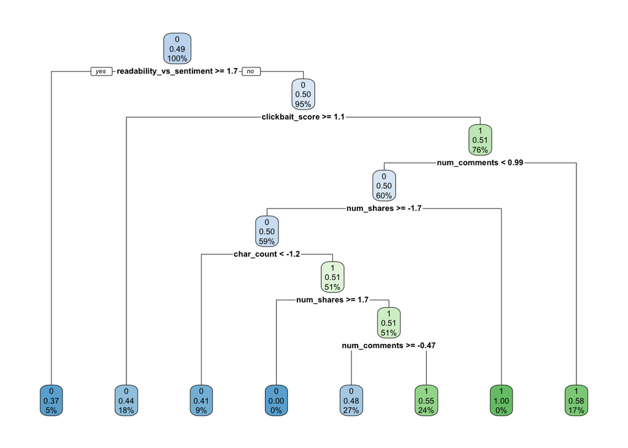

```r
fake_cart_model <- rpart(label ~ ., data = train_set, method = "class", parms = list(split = "gini"))

# Plot the tree
fake_cart_plot <- rpart.plot(fake_cart_model)
```

```r
fake_cart_plot
```

[output not shown]

[output cut: 71 more lines]

[output not shown]

### 3.5.2 CART Decision Tree Accuracy

```r
# Predict on validation set
cart_predictions <- predict(fake_cart_model, val_set, type = "class")

# Align factor levels
common_levels <- union(levels(val_set$label), levels(cart_predictions))
cart_predictions <- factor(cart_predictions, levels = common_levels)
val_set$label <- factor(val_set$label, levels = common_levels)

# Create confusion matrix
conf_matrix_cart <- confusionMatrix(cart_predictions, val_set$label)
conf_matrix_table <- table(cart_predictions, val_set$label)

conf_matrix_cart
```

```
## Confusion Matrix and Statistics
##
##           Reference
## Prediction   0   1
##          0 237 235
##          1 166 162
##
##                Accuracy : 0.4988
##                  95% CI : (0.4635, 0.534)
##     No Information Rate : 0.5038
##     P-Value [Acc > NIR] : 0.6248549
##
##                   Kappa : -0.0039
##
##  Mcnemar's Test P-Value : 0.0006844
##
##             Sensitivity : 0.5881
##             Specificity : 0.4081
##          Pos Pred Value : 0.5021
##          Neg Pred Value : 0.4939
##              Prevalence : 0.5038
##          Detection Rate : 0.2963
##    Detection Prevalence : 0.5900
##       Balanced Accuracy : 0.4981
##
##        'Positive' Class : 0
##
```

### 3.5.3 CART Pruning

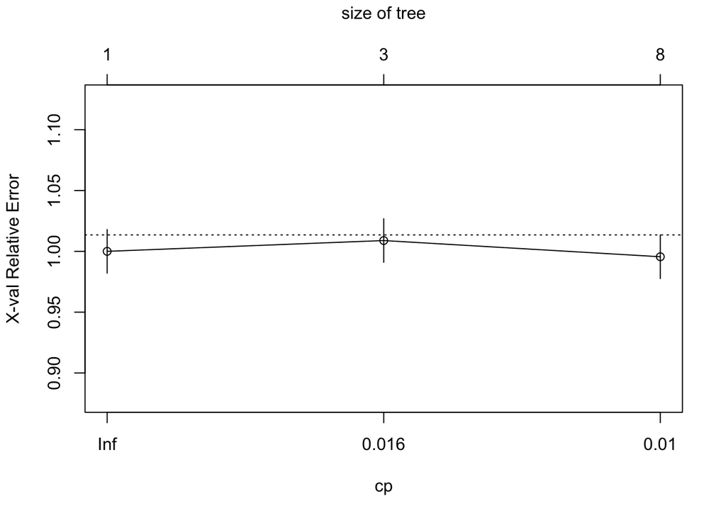

```r
full_cart_model <- rpart(label ~ ., data = train_set, method = "class")

# Plot cross-validation error to find optimal CP
plotcp(full_cart_model)
```

```r
printcp(full_cart_model)
```

```
##
## Classification tree:
## rpart(formula = label ~ ., data = train_set, method = "class")
##
## Variables actually used in tree construction:
## [1] char_count               clickbait_score          num_comments
## [4] num_shares               readability_vs_sentiment
##
## Root node error: 1577/3200 = 0.49281
##
## n= 3200
##
##         CP nsplit rel error  xerror     xstd
## 1 0.023145      0   1.00000 1.00000 0.017934
## 2 0.010991      2   0.95371 1.00888 0.017935
## 3 0.010000      7   0.89537 0.99556 0.017932
```

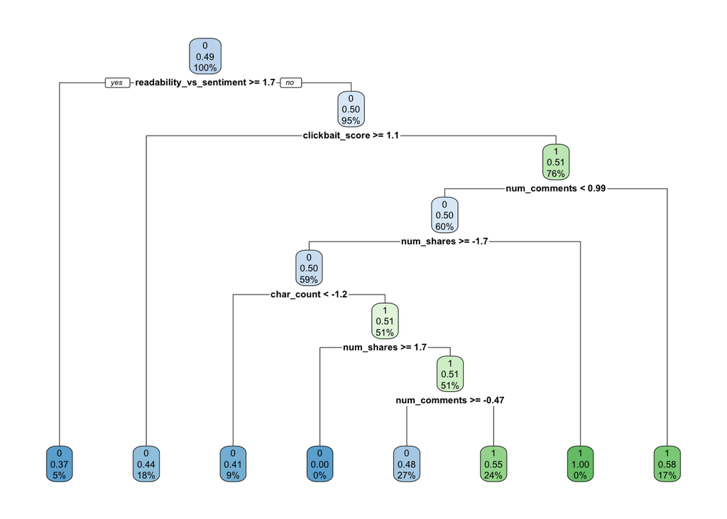

```r
# Identify optimal CP value (lowest cross-validated error)
optimal_cp <- full_cart_model$cptable[which.min(full_cart_model$cptable[, "xerror"]), "CP"]

# Prune the tree
pruned_cart_model <- prune(full_cart_model, cp = optimal_cp)

# Plot the pruned tree
rpart.plot(pruned_cart_model)
```

```r
# Predict using both models
original_cart_preds <- predict(full_cart_model, val_set, type = "class")
pruned_cart_preds <- predict(pruned_cart_model, val_set, type = "class")

# Align factor levels
all_levels <- union(levels(val_set$label), unique(c(levels(original_cart_preds), levels(pruned_cart_preds))))
original_cart_preds <- factor(original_cart_preds, levels = all_levels)
pruned_cart_preds <- factor(pruned_cart_preds, levels = all_levels)
val_set$label <- factor(val_set$label, levels = all_levels)

# Confusion matrices
original_cart_cm <- confusionMatrix(original_cart_preds, val_set$label)
pruned_cart_cm <- confusionMatrix(pruned_cart_preds, val_set$label)

# Print both
original_cart_cm
```

```
## Confusion Matrix and Statistics
##
##           Reference
## Prediction   0   1
##          0 237 235
##          1 166 162
##
##                Accuracy : 0.4988
##                  95% CI : (0.4635, 0.534)
##     No Information Rate : 0.5038
##     P-Value [Acc > NIR] : 0.6248549
##
##                   Kappa : -0.0039
##
##  Mcnemar's Test P-Value : 0.0006844
##
##             Sensitivity : 0.5881
##             Specificity : 0.4081
##          Pos Pred Value : 0.5021
##          Neg Pred Value : 0.4939
##              Prevalence : 0.5038
##          Detection Rate : 0.2963
##    Detection Prevalence : 0.5900
##       Balanced Accuracy : 0.4981
##
##        'Positive' Class : 0
##
```

```r
pruned_cart_cm
```

```
## Confusion Matrix and Statistics
##
##           Reference
## Prediction   0   1
##          0 237 235
##          1 166 162
##
##                Accuracy : 0.4988
##                  95% CI : (0.4635, 0.534)
##     No Information Rate : 0.5038
##     P-Value [Acc > NIR] : 0.6248549
##
##                   Kappa : -0.0039
##
##  Mcnemar's Test P-Value : 0.0006844
##
##             Sensitivity : 0.5881
##             Specificity : 0.4081
##          Pos Pred Value : 0.5021
##          Neg Pred Value : 0.4939
##              Prevalence : 0.5038
##          Detection Rate : 0.2963
##    Detection Prevalence : 0.5900
##       Balanced Accuracy : 0.4981
##
##        'Positive' Class : 0
##
```

Because CART Decision Tree isn’t strong enough, lets try the C5 model…

### 3.5.4 C5 Model and Accuracy

```r
train_set$label <- as.factor(train_set$label)

# Build the C5.0 model without boosting (trials = 1)
c50_model_no_boost <- C5.0(x = train_set[, -which(names(train_set) == "label")],
                           y = train_set$label,
                           trials = 1)

# Print summary
c50_model_no_boost
```

```
##
## Call:
## C5.0.default(x = train_set[, -which(names(train_set) == "label")], y
##  = train_set$label, trials = 1)
##
## Classification Tree
## Number of samples: 3200
## Number of predictors: 23
##
## Tree size: 18
##
## Non-standard options: attempt to group attributes
```

```r
c50_pred <- predict(c50_model_no_boost, val_set[, -which(colnames(val_set) == "label")])

# Align factor levels
c50_pred <- factor(c50_pred, levels = levels(factor(val_set$label)))
val_set$label <- factor(val_set$label, levels = levels(c50_pred))

# Confusion matrix
c50_conf_matrix <- confusionMatrix(c50_pred, val_set$label)

# View results
c50_conf_matrix
```

```
## Confusion Matrix and Statistics
##
##           Reference
## Prediction   0   1
##          0 224 228
##          1 179 169
##
##                Accuracy : 0.4912
##                  95% CI : (0.4561, 0.5265)
##     No Information Rate : 0.5038
##     P-Value [Acc > NIR] : 0.77110
##
##                   Kappa : -0.0185
##
##  Mcnemar's Test P-Value : 0.01735
##
##             Sensitivity : 0.5558
##             Specificity : 0.4257
##          Pos Pred Value : 0.4956
##          Neg Pred Value : 0.4856
##              Prevalence : 0.5038
##          Detection Rate : 0.2800
##    Detection Prevalence : 0.5650
##       Balanced Accuracy : 0.4908
##
##        'Positive' Class : 0
##
```

### 3.5.5 Boosted C5 and Accuracy

```r
c50_model_boost_10 <- C5.0(x = train_set[, -which(colnames(train_set) == "label")],
                           y = train_set$label,
                           trials = 50)

# Predict on validation set
c50_pred_boost_10 <- predict(c50_model_boost_10, val_set[, -which(colnames(val_set) == "label")])

# Align factor levels
c50_pred_boost_10 <- factor(c50_pred_boost_10, levels = levels(factor(val_set$label)))
val_set$label <- factor(val_set$label, levels = levels(c50_pred_boost_10))

# Confusion matrix
c50_conf_matrix_boost_10 <- confusionMatrix(c50_pred_boost_10, val_set$label)
c50_conf_matrix_boost_10
```

```
## Confusion Matrix and Statistics
##
##           Reference
## Prediction   0   1
##          0 194 196
##          1 209 201
##
##                Accuracy : 0.4938
##                  95% CI : (0.4586, 0.529)
##     No Information Rate : 0.5038
##     P-Value [Acc > NIR] : 0.7261
##
##                   Kappa : -0.0123
##
##  Mcnemar's Test P-Value : 0.5510
##
##             Sensitivity : 0.4814
##             Specificity : 0.5063
##          Pos Pred Value : 0.4974
##          Neg Pred Value : 0.4902
##              Prevalence : 0.5038
##          Detection Rate : 0.2425
##    Detection Prevalence : 0.4875
##       Balanced Accuracy : 0.4938
##
##        'Positive' Class : 0
##
```

### 3.5.6 CART Decision Tree F1 Score

```r
TP_CART <- conf_matrix_table["1", "1"]
TN_CART <- conf_matrix_table["0", "0"]
FP_CART <- conf_matrix_table["1", "0"]
FN_CART <- conf_matrix_table["0", "1"]

# Calculate Precision, Recall, and F1 Score
precision_CART <- TP_CART / (TP_CART + FP_CART)
recall_CART <- TP_CART / (TP_CART + FN_CART)
f1_score_CART <- 2 * (precision_CART * recall_CART) / (precision_CART + recall_CART)

f1_score_CART
```

```
## [1] 0.4468966
```

A score of **0.447** suggests that the model struggles with misclassifications—either it’s generating a lot of false positives, false negatives, or both.

## 3.6 kNN Model

To build the kNN model, I first ensured that the target variable label was treated as a factor. I then removed any irrelevant identifiers *(id)* to avoid bias in the distance calculations. Using 5-fold cross-validation, I trained the model with different odd-numbered k values from 1 to 19. The plot below shows how accuracy varied with each k, helping identify the most effective number of neighbors. This approach allowed me to tune k and avoid underfitting or overfitting, selecting the value that gave the highest validation accuracy.

### 3.6.1 Build Model

```r
train_set$label <- factor(train_set$label, levels = c(0, 1))
val_set$label <- factor(val_set$label, levels = c(0, 1))

# Optional: drop ID column if you have one (e.g., article_id or similar)
train_knn <- train_set %>% dplyr::select(-id)  # Replace `id` with actual ID col name if needed
val_knn <- val_set %>% dplyr::select(-id)

# 5-fold cross-validation setup
train_control <- trainControl(method = "cv", number = 5)

# Tune k from 1 to 19 (odd numbers)
knn_model <- train(
  label ~ .,
  data = train_knn,
  method = "knn",
  trControl = train_control,
  tuneGrid = expand.grid(k = seq(1, 19, by = 2))  # Try odd k-values only
)

# View results
knn_model
```

```
## k-Nearest Neighbors
##
## 3200 samples
##   22 predictor
##    2 classes: '0', '1'
##
## No pre-processing
## Resampling: Cross-Validated (5 fold)
## Summary of sample sizes: 2559, 2559, 2561, 2561, 2560
## Resampling results across tuning parameters:
##
##   k   Accuracy   Kappa
##    1  0.5081494  0.01594972
##    3  0.5259458  0.05167943
##    5  0.5112661  0.02221346
##    7  0.5278233  0.05541085
##    9  0.5221900  0.04377325
##   11  0.5203194  0.03980840
##   13  0.5181348  0.03549410
##   15  0.5253169  0.04983532
##   17  0.5284405  0.05621983
##   19  0.5231324  0.04543065
##
## Accuracy was used to select the optimal model using the largest value.
## The final value used for the model was k = 17.
```

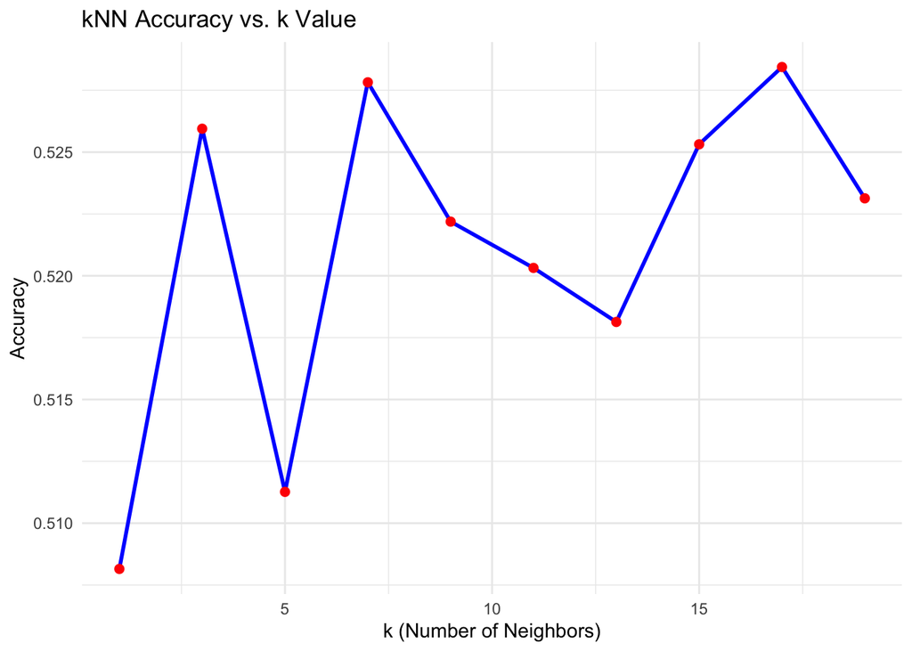

```r
# Plot accuracy vs. k where it displays the best k value
ggplot(knn_model$results, aes(x = k, y = Accuracy)) +
  geom_line(color = "blue", size = 1) +
  geom_point(color = "red", size = 2) +
  ggtitle("kNN Accuracy vs. k Value") +
  xlab("k (Number of Neighbors)") +
  ylab("Accuracy") +
  theme_minimal()
```

### 3.6.2 kNN Accuracy

```r
best_k <- knn_model$bestTune$k

# Prepare data
train_features <- train_knn %>% dplyr::select(-label)
val_features <- val_knn %>% dplyr::select(-label)
train_labels <- train_knn$label
val_labels <- val_knn$label

# Run kNN with best k
knn_predictions <- knn(
  train = train_features,
  test = val_features,
  cl = train_labels,
  k = best_k)

# Convert predictions and true labels to factor with same levels
knn_predictions <- factor(knn_predictions, levels = levels(val_labels))
val_labels <- factor(val_labels, levels = levels(knn_predictions))

conf_matrix_kNN <- confusionMatrix(knn_predictions, val_labels)
conf_matrix_kNN
```

```
## Confusion Matrix and Statistics
##
##           Reference
## Prediction   0   1
##          0 229 225
##          1 174 172
##
##                Accuracy : 0.5012
##                  95% CI : (0.466, 0.5365)
##     No Information Rate : 0.5038
##     P-Value [Acc > NIR] : 0.57019
##
##                   Kappa : 0.0015
##
##  Mcnemar's Test P-Value : 0.01231
##
##             Sensitivity : 0.5682
##             Specificity : 0.4332
##          Pos Pred Value : 0.5044
##          Neg Pred Value : 0.4971
##              Prevalence : 0.5038
##          Detection Rate : 0.2863
##    Detection Prevalence : 0.5675
##       Balanced Accuracy : 0.5007
##
##        'Positive' Class : 0
##
```

### 3.6.3 kNN F1-Score

```r
TP_KNN <- conf_matrix_kNN$table[2, 2]
FP_KNN <- conf_matrix_kNN$table[2, 1]
FN_KNN <- conf_matrix_kNN$table[1, 2]

precision_KNN <- TP_KNN / (TP_KNN + FP_KNN)

recall_KNN <- TP_KNN / (TP_KNN + FN_KNN)

# F1-Score
f1_score_KNN <- 2 * (precision_KNN * recall_KNN) / (precision_KNN + recall_KNN)

f1_score_KNN
```

```
## [1] 0.4629879
```

A score of **0.463** suggests that the model struggles with misclassifications—either it’s generating a lot of false positives, false negatives, or both.

## 3.7 Ensemble Model

To improve overall prediction accuracy, I created an ensemble model by averaging the predicted probabilities from three of my strongest individual models:

- Logistic Regression
- CART Decision Tree
- k-Nearest Neighbors (kNN)

Finally, I compared both of these ensembles against two advanced methods:

- **Stacked Ensemble:** A meta-decision tree learns how to combine predictions from individual models.
- **XGBoost Ensemble:** A gradient-boosted framework that improves accuracy by assigning higher weight to misclassified instances in earlier rounds.

### 3.7.1 Build Ensemble and Evaluate Accuracy

```r
# Logistic Regression probabilities
predicted_prob_logit <- predict(fake_log_model, newdata = val_set, type = "response")

# CART probabilities
predicted_prob_cart <- predict(fake_cart_model, newdata = val_set, type = "prob")[,2]

# kNN: Convert predicted classes to 1s and 0s since it's not a probabilistic model
knn_binary_preds <- as.numeric(as.character(knn_predictions))

# Convert all predictions to numeric
predicted_prob_logit <- as.numeric(predicted_prob_logit)
predicted_prob_cart <- as.numeric(predicted_prob_cart)

# Average probabilities across all four models
ensemble_probabilities <- (predicted_prob_logit + #nb_pred_probs
                             + predicted_prob_cart + knn_binary_preds) / 4

ensemble_predictions <- ifelse(ensemble_probabilities > 0.5, 1, 0)
ensemble_predictions <- factor(ensemble_predictions, levels = levels(val_set$label))

ensemble_conf_matrix <- confusionMatrix(ensemble_predictions, val_set$label)
ensemble_conf_matrix
```

```
## Confusion Matrix and Statistics
##
##           Reference
## Prediction   0   1
##          0 311 299
##          1  92  98
##
##                Accuracy : 0.5112
##                  95% CI : (0.476, 0.5464)
##     No Information Rate : 0.5038
##     P-Value [Acc > NIR] : 0.3487
##
##                   Kappa : 0.0186
##
##  Mcnemar's Test P-Value : <2e-16
##
##             Sensitivity : 0.7717
##             Specificity : 0.2469
##          Pos Pred Value : 0.5098
##          Neg Pred Value : 0.5158
##              Prevalence : 0.5038
##          Detection Rate : 0.3887
##    Detection Prevalence : 0.7625
##       Balanced Accuracy : 0.5093
##
##        'Positive' Class : 0
##
```

### 3.7.2 Ensemble F1 Score

```r
TP_ENSEMBLE <- ensemble_conf_matrix$table[2, 2]
FP_ENSEMBLE <- ensemble_conf_matrix$table[2, 1]
FN_ENSEMBLE <- ensemble_conf_matrix$table[1, 2]

precision_ENSEMBLE <- TP_ENSEMBLE / (TP_ENSEMBLE + FP_ENSEMBLE)
recall_ENSEMBLE <- TP_ENSEMBLE / (TP_ENSEMBLE + FN_ENSEMBLE)

f1_score_ENSEMBLE <- 2 * (precision_ENSEMBLE * recall_ENSEMBLE) / (precision_ENSEMBLE + recall_ENSEMBLE)

f1_score_ENSEMBLE
```

```
## [1] 0.3339012
```

A score of **0.334** suggests that the model struggles with misclassifications—either it’s generating a lot of false positives, false negatives, or both.

### 3.7.3 Weighted Ensemble

```r
ensemble_probabilities_weighted <- ( # Applying more weights to the best performing model of the three
  .5 * predicted_prob_logit +
  .3 * predicted_prob_cart +
  .1 * knn_binary_preds)

ensemble_preds_weighted <- ifelse(ensemble_probabilities_weighted > 0.5, 1, 0)
ensemble_preds_weighted <- factor(ensemble_preds_weighted, levels = levels(val_set$label))

conf_matrix_weighted <- confusionMatrix(ensemble_preds_weighted, val_set$label)
conf_matrix_weighted
```

```
## Confusion Matrix and Statistics
##
##           Reference
## Prediction   0   1
##          0 309 301
##          1  94  96
##
##                Accuracy : 0.5062
##                  95% CI : (0.471, 0.5414)
##     No Information Rate : 0.5038
##     P-Value [Acc > NIR] : 0.4578
##
##                   Kappa : 0.0086
##
##  Mcnemar's Test P-Value : <2e-16
##
##             Sensitivity : 0.7667
##             Specificity : 0.2418
##          Pos Pred Value : 0.5066
##          Neg Pred Value : 0.5053
##              Prevalence : 0.5038
##          Detection Rate : 0.3862
##    Detection Prevalence : 0.7625
##       Balanced Accuracy : 0.5043
##
##        'Positive' Class : 0
##
```

### 3.7.4 Stacking Boost Ensemble Build and Accuracy

```r
# Including all the predicted values from each model in a dataframe
stacking_data <- data.frame(
  logit = predicted_prob_logit,
  cart  = predicted_prob_cart,
  knn   = knn_binary_preds,
  label = val_set$label)

# Boosting by predicting again the stacked model and using the rpart()
stacked_tree_model <- rpart(label ~ ., data = stacking_data, method = "class")
stacked_tree_preds <- predict(stacked_tree_model, type = "class")
stacked_weighted_conf <- confusionMatrix(stacked_tree_preds, stacking_data$label)
stacked_weighted_conf
```

```
## Confusion Matrix and Statistics
##
##           Reference
## Prediction   0   1
##          0 240 152
##          1 163 245
##
##                Accuracy : 0.6062
##                  95% CI : (0.5714, 0.6403)
##     No Information Rate : 0.5038
##     P-Value [Acc > NIR] : 3.612e-09
##
##                   Kappa : 0.2126
##
##  Mcnemar's Test P-Value : 0.5731
##
##             Sensitivity : 0.5955
##             Specificity : 0.6171
##          Pos Pred Value : 0.6122
##          Neg Pred Value : 0.6005
##              Prevalence : 0.5038
##          Detection Rate : 0.3000
##    Detection Prevalence : 0.4900
##       Balanced Accuracy : 0.6063
##
##        'Positive' Class : 0
##
```

### 3.7.5 Boost with XGBoost Ensemble

```r
# Step 2: Prepare data for xgboost
stacking_matrix <- as.matrix(stacking_data %>% dplyr::select(-label))
stacking_label <- stacking_data$label

stacking_label <- as.numeric(as.character(stacking_data$label))

xgb_ensemble <- xgboost(
  data = stacking_matrix,
  label = stacking_label,
  nrounds = 150,
  objective = "binary:logistic",
  eval_metric = "error",
  verbose = 0)

# Step 4: Predict
ensemble_boost_probs <- predict(xgb_ensemble, stacking_matrix)
ensemble_boost_preds <- ifelse(ensemble_boost_probs > 0.5, 1, 0)
ensemble_boost_preds <- factor(ensemble_boost_preds, levels = levels(val_set$label))
val_set$label <- factor(val_set$label, levels = levels(ensemble_boost_preds))

confusionMatrix(ensemble_boost_preds, val_set$label)
```

```
## Confusion Matrix and Statistics
##
##           Reference
## Prediction   0   1
##          0 369  44
##          1  34 353
##
##                Accuracy : 0.9025
##                  95% CI : (0.8798, 0.9222)
##     No Information Rate : 0.5038
##     P-Value [Acc > NIR] : <2e-16
##
##                   Kappa : 0.805
##
##  Mcnemar's Test P-Value : 0.3082
##
##             Sensitivity : 0.9156
##             Specificity : 0.8892
##          Pos Pred Value : 0.8935
##          Neg Pred Value : 0.9121
##              Prevalence : 0.5038
##          Detection Rate : 0.4612
##    Detection Prevalence : 0.5162
##       Balanced Accuracy : 0.9024
##
##        'Positive' Class : 0
##
```

**EUREKA!!!**

# 4 **Final Model Evaluation**

## 4.1 XGBOOST Ensemble Model F1 Score

```r
xgb_conf_matrix <- confusionMatrix(ensemble_boost_preds, val_set$label)

TP_xgb <- xgb_conf_matrix$table[2, 2]
FP_xgb <- xgb_conf_matrix$table[2, 1]
FN_xgb <- xgb_conf_matrix$table[1, 2]

precision_xgb <- TP_xgb / (TP_xgb + FP_xgb)
recall_xgb <- TP_xgb / (TP_xgb + FN_xgb)
f1_score_xgb <- 2 * (precision_xgb * recall_xgb) / (precision_xgb + recall_xgb)

f1_score_xgb
```

```
## [1] 0.9005102
```

An F1 score of **0.90** for the XGBoost ensemble model indicates it performs very accurately performance. It can correctly identify both real and fake articles with very few classification errors.

## 4.2 Ensemble vs. Individual Models

We’ll compare our individual models created the the final XGBoost Model

```r
model_comparison_df <- data.frame(
  Model = c("Logistic Regression", "Naive Bayes", "CART", "kNN", "XGBoost Ensemble"),
  F1_Score = c(
    round(f1_score_log, 3),
    round(f1_score_nb, 3),
    round(f1_score_CART, 3),
    round(f1_score_KNN, 3),
    round(f1_score_xgb, 3)))

model_comparison_df
```

| Model | F1_Score |
| --- | --- |
| Logistic Regression | 0.474 |
| Naive Bayes | 0.015 |
| CART | 0.447 |
| kNN | 0.463 |
| XGBoost Ensemble | 0.901 |

The results show that Naive Bayes performed poorly with an F1 score of just 0.015, indicating it struggled to make meaningful predictions. Logistic Regression (0.474), kNN (0.463), and CART (0.447) delivered moderate performance but still left room for improvement.

## 4.3 Predicted vs. Actual

Below is a dataframe that’s printable to compare the predicted results from the XGBoost Ensemble Model and the individual models to the actual result from the original dataframe.

```r
comparison_df <- data.frame(
  Actual_Label        = val_set$label,
  Logistic_Prediction = predicted_classes_log,
  CART_Prediction     = cart_predictions,
  KNN_Prediction      = knn_predictions,
  NB_Prediction       = nb_prediction$class,
  XGBoost_Ensemble    = ensemble_boost_preds)

# Add columns for correct/incorrect flags for each model
comparison_df <- comparison_df %>%
  mutate(
    Correct_Logit     = Actual_Label == Logistic_Prediction,
    Correct_CART      = Actual_Label == CART_Prediction,
    Correct_KNN       = Actual_Label == KNN_Prediction,
    Correct_NB        = Actual_Label == NB_Prediction,
    Correct_XGBoost   = Actual_Label == XGBoost_Ensemble)

head(comparison_df, 10)
```

|  | Actual_Label | Logistic_Prediction | CART_Prediction | KNN_Prediction | NB_Prediction | XGBoost_Ensemble | Correct_Logit | Correct_CART | Correct_KNN | Correct_NB | Correct_XGBoost |
| --- | --- | --- | --- | --- | --- | --- | --- | --- | --- | --- | --- |
| 3 | 0 | 1 | 0 | 0 | 0 | 0 | FALSE | TRUE | TRUE | TRUE | TRUE |
| 6 | 0 | 1 | 1 | 1 | 0 | 0 | FALSE | FALSE | FALSE | TRUE | TRUE |
| 14 | 0 | 0 | 1 | 1 | 0 | 0 | TRUE | FALSE | FALSE | TRUE | TRUE |
| 22 | 0 | 0 | 0 | 1 | 0 | 0 | TRUE | TRUE | FALSE | TRUE | TRUE |
| 43 | 1 | 1 | 1 | 0 | 0 | 1 | TRUE | TRUE | FALSE | FALSE | TRUE |
| 47 | 1 | 0 | 0 | 1 | 0 | 1 | FALSE | FALSE | TRUE | FALSE | TRUE |
| 50 | 1 | 0 | 0 | 0 | 0 | 1 | FALSE | FALSE | FALSE | FALSE | TRUE |
| 53 | 1 | 1 | 0 | 1 | 0 | 1 | TRUE | FALSE | TRUE | FALSE | TRUE |
| 57 | 0 | 0 | 0 | 0 | 0 | 0 | TRUE | TRUE | TRUE | TRUE | TRUE |
| 58 | 1 | 0 | 0 | 0 | 0 | 1 | FALSE | FALSE | FALSE | FALSE | TRUE |

# 5 **Deployment Plan**

**Objective:**

Deploy a high-performing XGBoost ensemble model that classifies news articles as Real or Fake to support real-time or batch prediction use cases for media companies, PR firms, or fact-checking platforms. Below are the steps to take from here…

- 1: Save the Trained Model
- 2: Create a Prediction Pipeline
- 3: Choose a Deployment Method
- 4: Model Monitoring & Maintenance

# 6 **Conclusion**

This project explored multiple classification algorithms to predict whether a news article is “Real” or “Fake,” each selected for its unique strengths. I chose Logistic Regression for its interpretability, Decision Trees (CART and C5) for their ability to capture non-linear relationships, Naive Bayes for its simplicity and speed, and k-Nearest Neighbors for its proximity-based logic after normalization.

To improve performance, I experimented with ensemble methods, starting with a weighted average of the top-performing models (Logistic, CART, kNN), and ultimately building a stacked model and an XGBoost-based ensemble. These combinations were selected to balance interpretability of the data, computational efficiency, and predictive power. The XGBoost ensemble significantly outperformed the individual models, demonstrating the power of boosting when applied to well-preprocessed features.

Through this process, I gained a deeper understanding of what it takes to build an ideal classification model. Every model had trade-offs—some favored precision, others recall—reinforcing the “No Free Lunch” theorem, which reminds us there is no single best algorithm for every problem. The key is to build a diverse set of models, understand their assumptions, and thoughtfully combine their strengths for the best outcome.

Ultimately, the best-performing solution was not a single algorithm, but a carefully tuned ensemble that synthesized insights from multiple perspectives—just like the real-world decisions it was designed to support.